# 평가문제풀이

김용태

2018년 8월 10일

# 1. “Bankruptcy.csv“파일은 총 46개의 현재 재무구조가 건실한 기업과 파산한 기업들에 대한 2년전 재무상황자료이다. 이 자료를 이용하여 건실기업과 파산기업을 판별하시오.

> 데이터 불러오기

```r
B.data<-read.csv('Bankruptcy.csv', skip=6, header=T)
B.data$group<-factor(B.data$group, levels=1:2, labels=c("파산기업", "건실기업"))
head(B.data)
```

```
##      X1    X2   X3   X4    group
## 1 -0.45 -0.41 1.09 0.45 파산기업
## 2 -0.56 -0.31 1.51 0.16 파산기업
## 3  0.06  0.02 1.01 0.40 파산기업
## 4 -0.07 -0.09 1.45 0.26 파산기업
## 5 -0.10 -0.09 1.56 0.67 파산기업
## 6 -0.14 -0.07 0.71 0.28 파산기업
```

```r
tail(B.data)
```

```
##      X1   X2   X3   X4    group
## 41 0.48 0.09 1.24 0.18 건실기업
## 42 0.56 0.11 4.29 0.45 건실기업
## 43 0.20 0.08 1.99 0.30 건실기업
## 44 0.47 0.14 2.92 0.45 건실기업
## 45 0.17 0.04 2.45 0.14 건실기업
## 46 0.58 0.04 5.06 0.13 건실기업
```

## (1) 두 집단의 공분산이 같다고 할 수 있는지 유의수준 5%에서 가설검정 하시오.

> 공분산행렬의 동일성 검정

```r
library(biotools)
boxM(B.data[,c("X1", "X2", "X3", "X4")], grouping=B.data$group)
```

```
##
##  Box's M-test for Homogeneity of Covariance Matrices
##
## data:  B.data[, c("X1", "X2", "X3", "X4")]
## Chi-Sq (approx.) = 64.049, df = 10, p-value = 6.159e-10
```

```r
qchisq(0.05, 10, lower.tail=F)  # 기각치
```

```
## [1] 18.30704
```

```r
detach("package:biotools", unload=TRUE)
```

## (2) 위 (1) 검정결과를 이용하여 선형판별함수 또는 이차판별함수를 선택하여 추정하시오(변수선택법 사용, set.seed(456789), criterion=“AC”). 또 추정된 판별함수를 이용한 판별결과를 이용하여 분류표 작성과 정분류율을 계산하시오.

> 판별함수변수선택과 그래프

```r
library(klaR) # klaR 패키지 실행
step.result<-stepclass(group~., data=B.data, method="qda", improvement=0.001, criterion="AC")
```

```
##  `stepwise classification', using 10-fold cross-validated accuracy of method qda'.
```

```
## 46 observations of 4 variables in 2 classes; direction: both
```

```
## stop criterion: improvement less than 0.1%.
```

```
## accuracy: 0.48357;  in: "X3";  variables (1): X3
## accuracy: 0.60128;  in: "X2";  variables (2): X3, X2
## accuracy: 0.65069;  in: "X1";  variables (3): X3, X2, X1
## accuracy: 0.69684;  in: "X4";  variables (4): X3, X2, X1, X4
##
##  hr.elapsed min.elapsed sec.elapsed
##        0.00        0.00        0.47
```

```r
step.result
```

```
## method      : qda
## final model : group ~ X1 + X2 + X3 + X4
## <environment: 0x10afc1d8>
##
## accuracy = 0.6968
```

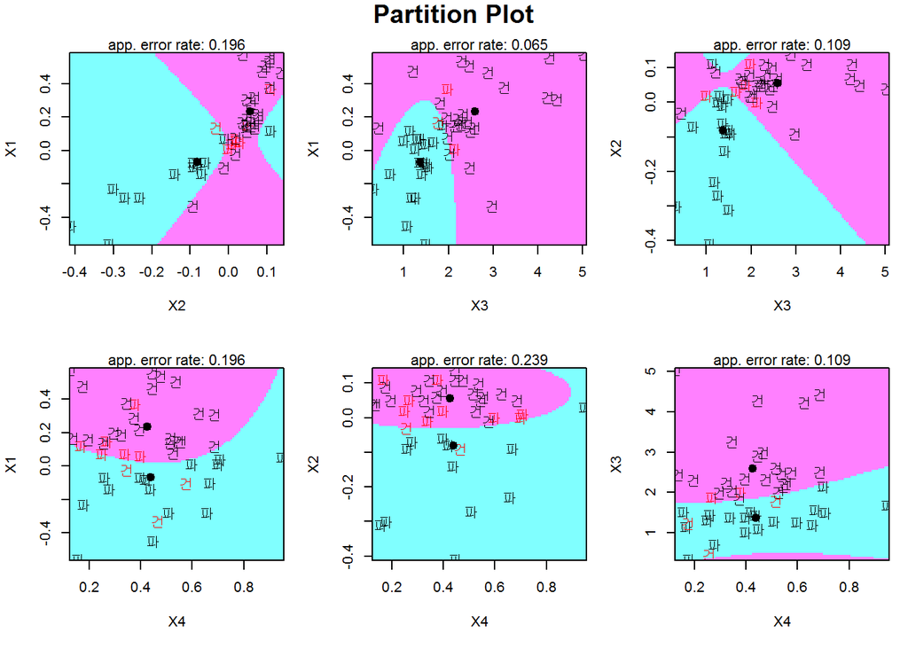

```r
partimat(B.data[,step.result$model$name], grouping=B.data$group, method="qda", plot.matrix=FALSE, imageplot=TRUE)
```

```r
detach("package:klaR", unload=TRUE)
```

> 최종 이차판별함수

```r
library(MASS)
step.result$formula
```

```
## group ~ X1 + X2 + X3 + X4
## <environment: 0x10afc1d8>
```

```r
result<-qda(step.result$formula, data=B.data)  # 최종 이차판별함수
new.g<-predict(result)$class # 예측범주
detach("package:MASS", unload=TRUE)
```

> 이차판별함수 분류표 및 정분류율

```r
xtabs(~new.g+B.data$group)  # 분류표
```

```
##           B.data$group
## new.g      파산기업 건실기업
##   파산기업       19        1
##   건실기업        2       24
```

```r
sum(new.g==B.data$group)/nrow(B.data) # 정분류율
```

```
## [1] 0.9347826
```

## (3) 로지스틱 회귀모형식을 작성하시오.(단계적 변수선택법 사용)

```r
logit.result<-glm(group~X1+X2+X3+X4, family=binomial, data=B.data)  # 로지스틱회귀모형
step.result<-step(logit.result, direction="both") # 로지스틱 회귀모형 변수선택
```

```
## Start:  AIC=37.44
## group ~ X1 + X2 + X3 + X4
##
##        Df Deviance    AIC
## - X2    1   27.512 35.512
## - X4    1   28.514 36.514
## - X1    1   29.129 37.129
## <none>      27.438 37.438
## - X3    1   42.560 50.560
##
## Step:  AIC=35.51
## group ~ X1 + X3 + X4
##
##        Df Deviance    AIC
## - X4    1   28.636 34.636
## <none>      27.512 35.512
## + X2    1   27.438 37.438
## - X1    1   32.748 38.748
## - X3    1   43.625 49.625
##
## Step:  AIC=34.64
## group ~ X1 + X3
##
##        Df Deviance    AIC
## <none>      28.636 34.636
## + X4    1   27.512 35.512
## + X2    1   28.514 36.514
## - X1    1   35.344 39.344
## - X3    1   43.650 47.650
```

```r
summary(step.result)  # 최종 로지스틱 회귀모형 요약통계량
```

```
##
## Call:
## glm(formula = group ~ X1 + X3, family = binomial, data = B.data)
##
## Deviance Residuals:
##      Min        1Q    Median        3Q       Max
## -2.26853  -0.47678   0.00942   0.48365   2.70538
##
## Coefficients:
##             Estimate Std. Error z value Pr(>|z|)
## (Intercept)   -5.940      1.985  -2.992  0.00277 **
## X1             6.556      2.905   2.257  0.02402 *
## X3             3.019      1.002   3.013  0.00259 **
## ---
## Signif. codes:  0 '***' 0.001 '**' 0.01 '*' 0.05 '.' 0.1 ' ' 1
##
## (Dispersion parameter for binomial family taken to be 1)
##
##     Null deviance: 63.421  on 45  degrees of freedom
## Residual deviance: 28.636  on 43  degrees of freedom
## AIC: 34.636
##
## Number of Fisher Scoring iterations: 6
```

```r
pchisq(step.result$deviance, step.result$df.residual, lower.tail=F) # 이탈도 p-값
```

```
## [1] 0.9546163
```

## (4) 추정된 로지스틱 회귀모형식에서 각 독립변수의 오즈 증가량을 구하고 이에 대한 해석을 작성하시오.

```r
exp(coefficients(step.result))  # 오즈비
```

```
##  (Intercept)           X1           X3
## 2.631605e-03 7.037443e+02 2.047321e+01
```

## (5) 로지스틱 회귀모형식에 의해서 판별한 결과를 이용하여 분류표 작성과 정분류율을 계산하시오.

```r
p.hat<-predict(step.result, type='response') # 예측 확률
hat.data<-cbind(B.data, hat.Y=factor(as.numeric(p.hat>=0.5), levels=0:1, labels=c("파산기업", "건실기업"))) # 예측
with(hat.data, table(hat.Y, group)) # 분류표
```

```
##           group
## hat.Y      파산기업 건실기업
##   파산기업       18        1
##   건실기업        3       24
```

```r
sum(with(hat.data, hat.Y==group))/NROW(B.data) # 정분류율
```

```
## [1] 0.9130435
```

# 2. “voter.txt”는 미국 대선 후보의 지지자들에 대한 조사 자료이다. 이 자료를 이용하여 연령과 성별, 학력수준에 따라서 어떤 후보를 지지하는지 알아보고자 한다. 전체 자료 중에서 학습자료 60%와 검정자료 40%로 나누어서 작업하시오.(단, 학습자료, 검정자료의 표본추출시 set.seed(12345))

## (1) Naive Bayes 분류방법을 이용하여 분류해보시오.

> 데이터 불러오기

```r
voter<-read.table("voter.txt", skip=5, header=T)
head(voter)
```

```
##   candidate age educ gender
## 1    힐러리  79   12   남자
## 2    힐러리  32   17   남자
## 3    힐러리  50    6   여자
## 4    힐러리  56    8   여자
## 5    힐러리  51   17   여자
## 6    힐러리  48   12   남자
```

```r
tail(voter)
```

```
##      candidate age educ gender
## 1842    트럼프  62   12   남자
## 1843    힐러리  35   16   남자
## 1844    트럼프  42   12   여자
## 1845    트럼프  40   12   남자
## 1846    힐러리  36    9   남자
## 1847    트럼프  33   12   여자
```

> 훈련자료와 검정자료

```r
set.seed(12345)
(n<-nrow(voter))  # 데이터 크기
```

```
## [1] 1847
```

```r
(m<-ceiling(n*0.6)) # 학습자료 60%
```

```
## [1] 1109
```

```r
tr.idx<-sort(sample(1:n, m, replace=F)) # 학습자료 index
tr.data<-voter[tr.idx, ] # 학습자료 60% 추출
ts.data<-voter[-tr.idx, ] # 검정자료 40% 추출
```

> 나이브 베이지안 분류 및 분류표, 정분류율

```r
library(e1071)
nb.model<-naiveBayes(tr.data[,c("age", "educ", "gender")], tr.data$candidate, laplace=0 ) # 나이브 베이지안 분류
nb.model
```

```
##
## Naive Bayes Classifier for Discrete Predictors
##
## Call:
## naiveBayes.default(x = tr.data[, c("age", "educ", "gender")],
##     y = tr.data$candidate, laplace = 0)
##
## A-priori probabilities:
## tr.data$candidate
## 버니샌더스     트럼프     힐러리
##  0.1568981  0.3678990  0.4752029
##
## Conditional probabilities:
##                  age
## tr.data$candidate     [,1]     [,2]
##        버니샌더스 40.64368 12.31896
##        트럼프     48.95588 17.01244
##        힐러리     48.72676 16.60928
##
##                  educ
## tr.data$candidate     [,1]     [,2]
##        버니샌더스 14.11494 2.293118
##        트럼프     14.12500 2.678802
##        힐러리     13.84440 3.170456
##
##                  gender
## tr.data$candidate      남자      여자
##        버니샌더스 0.5574713 0.4425287
##        트럼프     0.4558824 0.5441176
##        힐러리     0.3472486 0.6527514
```

```r
result<-predict(nb.model , ts.data[,c("age", "educ", "gender")])

table(result, ts.data$candidate) # 분류표
```

```
##
## result       버니샌더스 트럼프 힐러리
##   버니샌더스          7     15      8
##   트럼프             41     89    104
##   힐러리             56    149    269
```

```r
acc<-mean(result==ts.data$candidate)   # 분류율
acc
```

```
## [1] 0.4945799
```

```r
detach("package:e1071", unload=TRUE)
```

## (2) 연령(age)과 피교육년수(educ)를 그룹화하여 위와 동일하게 Naive Bayes 분류방법을 이용하여 분류해보시오.

> 연령과 피교육년수 그룹화

```r
age.g<-ifelse(voter$age<30, 1, ifelse(voter$age<40, 2, ifelse(voter$age<50, 3, ifelse(voter$age<60, 4, 5))))
age.g<-factor(age.g, levels=1:5, labels=c("30세 미만", "30대", "40대", "50대", "60대 이상"))
educ.g<-ifelse(voter$educ<10, 1, ifelse(voter$educ<13, 2, ifelse(voter$educ<16, 3, ifelse(voter$educ<18, 4, 5))))
educ.g<-factor(educ.g, levels=1:5, labels=c("고등학교 미만", "고등학교", "전문대학교", "대학교", "대학원"))
```

> 훈련자료와 검정자료

```r
new.voter<-cbind(voter, age.g, educ.g)
tr.data<-new.voter[tr.idx, ] # 학습자료 60% 추출
ts.data<-new.voter[-tr.idx, ] # 검정자료 40% 추출
```

> 나이브 베이지안 분류 및 분류표, 정분류율

```r
library(e1071)
nb.model<-naiveBayes(tr.data[,c("age.g", "educ.g", "gender")], tr.data$candidate, laplace=1) # 나이브 베이지안 분류
nb.model
```

```
##
## Naive Bayes Classifier for Discrete Predictors
##
## Call:
## naiveBayes.default(x = tr.data[, c("age.g", "educ.g", "gender")],
##     y = tr.data$candidate, laplace = 1)
##
## A-priori probabilities:
## tr.data$candidate
## 버니샌더스     트럼프     힐러리
##  0.1568981  0.3678990  0.4752029
##
## Conditional probabilities:
##                  age.g
## tr.data$candidate  30세 미만       30대       40대       50대  60대 이상
##        버니샌더스 0.16759777 0.36871508 0.24581006 0.12290503 0.09497207
##        트럼프     0.12590799 0.21791768 0.23970944 0.13801453 0.27845036
##        힐러리     0.13345865 0.19924812 0.24060150 0.16917293 0.25751880
##
##                  educ.g
## tr.data$candidate 고등학교 미만   고등학교 전문대학교     대학교
##        버니샌더스    0.01675978 0.31843575 0.32960894 0.25139665
##        트럼프        0.03147700 0.32687651 0.29297821 0.23728814
##        힐러리        0.07894737 0.33082707 0.24812030 0.20112782
##                  educ.g
## tr.data$candidate     대학원
##        버니샌더스 0.08379888
##        트럼프     0.11138015
##        힐러리     0.14097744
##
##                  gender
## tr.data$candidate      남자      여자
##        버니샌더스 0.5568182 0.4431818
##        트럼프     0.4560976 0.5439024
##        힐러리     0.3478261 0.6521739
```

```r
result<-predict(nb.model , ts.data[,c("age.g", "educ.g", "gender")])

table(result, ts.data$candidate) # 분류표
```

```
##
## result       버니샌더스 트럼프 힐러리
##   버니샌더스          0      0      0
##   트럼프             36     72     81
##   힐러리             68    181    300
```

```r
acc<-mean(result==ts.data$candidate)   # 분류율
acc
```

```
## [1] 0.504065
```

```r
detach("package:e1071", unload=TRUE)
```

# 3. “EgyptSkull.csv”은 이집트인의 두개골에 대한 자료이다. 이 자료를 이용하여 연대(Year)를 예측할 수 있는 최적의 SVM(모수조율 방법)과 신경망 모형(nnet 패키지)을 작성하시오. 전체 자료 중에서 학습자료 70%와 검정자료 30%로 나누어서 작업하시오.(단, 학습자료, 검정자료의 표본추출시와 신경망 훈련시 set.seed(12345))

> 데이터 불러오기

```r
ES.data<-read.csv('EgyptSkull.csv', skip=7, header=T)
ES.data$Year<-factor(ES.data$Year)
head(ES.data)
```

```
##   No.  X1  X2  X3 X4  Year
## 1   1 131 138  89 49 -4000
## 2   2 125 131  92 48 -4000
## 3   3 131 132  99 50 -4000
## 4   4 119 132  96 44 -4000
## 5   5 136 143 100 54 -4000
## 6   6 138 137  89 56 -4000
```

```r
tail(ES.data)
```

```
##     No.  X1  X2  X3 X4 Year
## 145 145 132 127  97 52  150
## 146 146 137 125  85 57  150
## 147 147 129 128  81 52  150
## 148 148 140 135 103 48  150
## 149 149 147 129  87 48  150
## 150 150 136 133  97 51  150
```

> 학습자료(70%)와 검정자료(30%)

```r
set.seed(12345)
(n<-nrow(ES.data))  # 데이터 크기
```

```
## [1] 150
```

```r
(m<-ceiling(n*0.7)) # 학습자료 70%
```

```
## [1] 105
```

```r
tr.idx<-sort(sample(1:n, m, replace=F)) # 학습자료 index
tr.data<-ES.data[tr.idx, ] # 학습자료 70% 추출
ts.data<-ES.data[-tr.idx, ] # 검정자료 30% 추출
```

> SVM 훈련자료 초모수 조율

```r
library(e1071)
tuned<-tune(svm, Year~., data=tr.data[,-1], type="C-classification", kernel='radial', ranges=list(cost=seq(100, 1000, length=21), gamma=seq(0.000001, 0.1, length=31)))
tuned
```

```
##
## Parameter tuning of 'svm':
##
## - sampling method: 10-fold cross validation
##
## - best parameters:
##  cost     gamma
##   820 0.0033343
##
## - best performance: 0.6854545
```

```r
str(tuned)
```

[output not shown]

[output cut: 35 more lines]

[output not shown]

```r
hp<-as.numeric(tuned$best.parameters)
model<-svm(Year~., data=tr.data[,-1], type="C-classification", kernel='radial', cost=hp[1], gamma=hp[2])
model
```

```
##
## Call:
## svm(formula = Year ~ ., data = tr.data[, -1], type = "C-classification",
##     kernel = "radial", cost = hp[1], gamma = hp[2])
##
##
## Parameters:
##    SVM-Type:  C-classification
##  SVM-Kernel:  radial
##        cost:  820
##       gamma:  0.0033343
##
## Number of Support Vectors:  102
```

```r
detach("package:e1071", unload=TRUE)
```

> SVM 검정자료 예측 및 정확도

```r
pred<-predict(model, newdata=ts.data[,-c(1,6)])

library(gmodels)
CrossTable(pred, ts.data$Year, prop.chisq=FALSE, prop.t=FALSE, prop.r=FALSE, dnn=c('predicted', 'actual'))  # 분류표
```

```
##
##
##    Cell Contents
## |-------------------------|
## |                       N |
## |           N / Col Total |
## |-------------------------|
##
##
## Total Observations in Table:  45
##
##
##              | actual
##    predicted |     -4000 |     -3300 |     -1850 |      -200 |       150 | Row Total |
## -------------|-----------|-----------|-----------|-----------|-----------|-----------|
##        -4000 |         2 |         5 |         1 |         1 |         1 |        10 |
##              |     0.250 |     0.500 |     0.143 |     0.083 |     0.125 |           |
## -------------|-----------|-----------|-----------|-----------|-----------|-----------|
##        -3300 |         3 |         2 |         1 |         5 |         2 |        13 |
##              |     0.375 |     0.200 |     0.143 |     0.417 |     0.250 |           |
## -------------|-----------|-----------|-----------|-----------|-----------|-----------|
##        -1850 |         1 |         3 |         2 |         0 |         0 |         6 |
##              |     0.125 |     0.300 |     0.286 |     0.000 |     0.000 |           |
## -------------|-----------|-----------|-----------|-----------|-----------|-----------|
##         -200 |         1 |         0 |         2 |         3 |         4 |        10 |
##              |     0.125 |     0.000 |     0.286 |     0.250 |     0.500 |           |
## -------------|-----------|-----------|-----------|-----------|-----------|-----------|
##          150 |         1 |         0 |         1 |         3 |         1 |         6 |
##              |     0.125 |     0.000 |     0.143 |     0.250 |     0.125 |           |
## -------------|-----------|-----------|-----------|-----------|-----------|-----------|
## Column Total |         8 |        10 |         7 |        12 |         8 |        45 |
##              |     0.178 |     0.222 |     0.156 |     0.267 |     0.178 |           |
## -------------|-----------|-----------|-----------|-----------|-----------|-----------|
##
##
```

```r
detach("package:gmodels", unload=TRUE)

acc<-mean(pred==ts.data$Year) # 분류율
acc
```

```
## [1] 0.2222222
```

> 신경망 학습

```r
library(nnet)
set.seed(12345)
model<-nnet(Year~., data=tr.data[,-1], size=5, rang=0.00001, decay=0.0001, maxit=500)
pred<-predict(model, newdata=ts.data[,-c(1,6)], type="class")  # 범주로 예측값 반환
detach("package:nnet", unload=TRUE)
```

> 신경망 검정자료 예측 및 정확도

```r
library(gmodels)
CrossTable(pred, ts.data$Year, prop.chisq=FALSE, prop.t=FALSE, prop.r=FALSE, dnn=c('predicted', 'actual'))  # 분류표
```

```
##
##
##    Cell Contents
## |-------------------------|
## |                       N |
## |           N / Col Total |
## |-------------------------|
##
##
## Total Observations in Table:  45
##
##
##              | actual
##    predicted |     -4000 |     -3300 |     -1850 |      -200 |       150 | Row Total |
## -------------|-----------|-----------|-----------|-----------|-----------|-----------|
##        -1850 |         3 |         2 |         5 |         4 |         2 |        16 |
##              |     0.375 |     0.200 |     0.714 |     0.333 |     0.250 |           |
## -------------|-----------|-----------|-----------|-----------|-----------|-----------|
##        -4000 |         4 |         8 |         0 |         3 |         1 |        16 |
##              |     0.500 |     0.800 |     0.000 |     0.250 |     0.125 |           |
## -------------|-----------|-----------|-----------|-----------|-----------|-----------|
##          150 |         1 |         0 |         2 |         5 |         5 |        13 |
##              |     0.125 |     0.000 |     0.286 |     0.417 |     0.625 |           |
## -------------|-----------|-----------|-----------|-----------|-----------|-----------|
## Column Total |         8 |        10 |         7 |        12 |         8 |        45 |
##              |     0.178 |     0.222 |     0.156 |     0.267 |     0.178 |           |
## -------------|-----------|-----------|-----------|-----------|-----------|-----------|
##
##
```

```r
detach("package:gmodels", unload=TRUE)

acc<-mean(pred==ts.data$Year) # 분류율
acc
```

```
## [1] 0.3111111
```

> 신경망 시각화

```r
library(devtools)
source_url('https://gist.githubusercontent.com/Peque/41a9e20d6687f2f3108d/raw/85e14f3a292e126f1454864427e3a189c2fe33f3/nnet_plot_update.r')
```

```
## SHA-1 hash of file is bf3c7b8ac910823b729e3ce73bb6ab5e6955ad3d
```

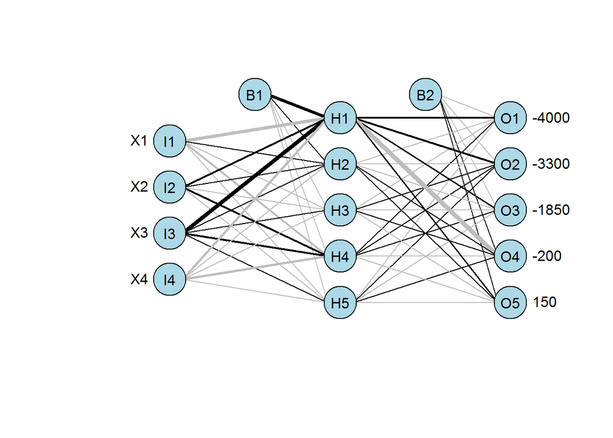

```r
windows()
plot.nnet(model)
```

```r
detach("package:devtools", unload=TRUE)
```